# Clase 7: Introduccion a R markdown

Natalia Esquenazi y Franco Cellone

27/01/2021

[figure not shown]

## R Markdown

R Markdown provee un marco de escritura para ciencia de datos, que combina tu código, sus resultados y tus comentarios en prosa. Los documentos de R Markdown son completamente reproducibles y soportan docenas de formatos de salida tales como PDFs, archivos de Word, presentaciones y más (Hadley Wickam).

## Como abrir un archivo

File > New File > R Markdown > Title > Author > Tipo de documento (html, pdf) > Save

## Partes de Markdown

1. Encabezado YAML(yet another markup language)
2. Bloques de codigo o chunks: los abrimos seleccionando insert o Crt+Alt+I
   - Nombre
   - eval = FALSE evita que el código sea evaluado
   - include = FALSE ejecuta el código, pero no muestra el código
   - echo = FALSE evita que se vea el código, pero sí muestra los resultados en el archivo final
   - message = FALSE o warning = FALSE evita que aparezcan mensajes o advertencias en el archivo final
   - results = ‘hide’ oculta el output impreso
   - fig.show = ‘hide’ oculta gráficos
   - error = TRUE causa que el render continúe ejecutando incluso si el código devuelve un error

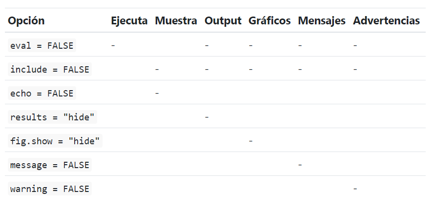

```r
#Creamos los ocupados

Poblacion_ocupados <- eph.1.20 %>%
  summarise(Poblacion         = sum(PONDERA),
            Ocupados          = sum(PONDERA[ESTADO == 1]))
Poblacion_ocupados
```

[figure not shown]

3. Bloques de texto

Titulo en negrita:

## **Datos**

Titulo normal:

## Datos

Titulo con items:

### Datos

- *Ejemplo*
- *Ejemplo*